# Рекомендация тарифных планов оператора мобильной связи

Абоненты используют тарифные планы операторов мобильной связи как базовые договоры при использовании услуг мобильной связи и интернета и их оплаты.

Увеличение потребительского спроса на различные виды связи, дифференциация этого спроса, технологический прогресс, желание мобильного оператора увеличить доход и конкуренция с другими операторами — всё это приводит к появлению новых тарифных планов.

Тарифный план, который более недоступен для подключения, является архивным. Старые тарифные планы становятся архивными, потому что они менее выгодны сотовому оператору, чем новые тарифные планы, и не всегда могут в полной мере удовлетворить спрос абонентов. Меняется структура спроса абонентов на различные виды связи, что может приводить к потере актуальности существующих тарифных планов.

В свою очередь, действующий, или актуальный тарифный план — тарифный план, который в настоящее время доступен для подключения или переход на который возможен с другого тарифного плана, в том числе архивного.

У каждого оператора существует несколько тарифных планов: они отличаются друг от друга и набором услуг, и их качеством. Каждый оператор с целью более удобного ориентирования клиентов, а также в рекламных целях, даёт своим тарифным планам определённые названия.

В нашем распоряжении данные о поведении абонентов, которые уже перешли на тарифные планы "Ультра" и "Смарт". Для каждого абонента доступна информация о количестве совершённых звонков и их суммарной длительности, о количестве отправленных смс-сообщений и об объёме израсходованного интернет-трафика.

Чтобы предложить пользователям архивных тарифных планов новые, нужно провести анализ их потребностей. Определить, сколько они потребляют голосовых минут, сообщений и интернет-трафика в месяц, и какие услуги им наиболее важны. Сравнить эту информацию с тарифными планами, которые имеются у мобильного оператора.

Для того чтобы определить тарифный план, который будет соответствовать потребностям абонента, нужно построить модель, которая сможет проанализировать данные о количестве совершённых звонков, о расходе минут, смс и интернет-трафика в месяц и предложит наиболее подходящий тарифный план — "Ультра" или "Смарт".

**Цель проекта:** построить модель, которая выберет подходящий тарифный план.

**Задачи проекта:**

- выполнить предобработку данных (при необходимости);
- провести описательный анализ данных;
- разбить данные на тренировочную и валидационную выборки (при необходимости выделить тестовую выборку);
- выбрать алгоритмы и построить модели;
- выбрать метрики качества моделей и оценить их значения.

# Содержание

## Обзор данных

### Импорт библиотек и предварительные настройки

```python
import pandas as pd
import matplotlib.pyplot as plt
import numpy as np
import seaborn as sns
import sys
import os

from sklearn.model_selection import train_test_split
from sklearn.tree import DecisionTreeClassifier
from sklearn.ensemble import RandomForestClassifier
from sklearn.linear_model import LogisticRegression
from sklearn.metrics import accuracy_score

pd.set_option('display.max_columns', None)
np.set_printoptions(threshold=sys.maxsize)

RANDOM_STATE = 1
```

### Чтение файла и загрузка данных

Все данные хранятся в одном файле.  
Файл данных `users_behavior.csv` имеет формат `CSV`.

```python
pth1 = r'C:\Users\Георгий\Documents\DS_projects\users_behavior.csv'
pth2 = '/datasets/users_behavior.csv'
pth3 = '/content/users_behavior.csv'

if os.path.exists(pth1):
    data = pd.read_csv(pth1)
elif os.path.exists(pth2):
    data = pd.read_csv(pth2)
elif os.path.exists(pth3):
    data = pd.read_csv(pth3)
else:
    print('Something is wrong')
```

Убедимся, что данные подгрузились верно, без ошибок.

Для этого выведем первые 10 строк и последние 10 строк набора данных.

```python
data.head(10)
```

|  | calls | minutes | messages | mb_used | is_ultra |
| --- | --- | --- | --- | --- | --- |
| 0 | 40.0 | 311.90 | 83.0 | 19915.42 | 0 |
| 1 | 85.0 | 516.75 | 56.0 | 22696.96 | 0 |
| 2 | 77.0 | 467.66 | 86.0 | 21060.45 | 0 |
| 3 | 106.0 | 745.53 | 81.0 | 8437.39 | 1 |
| 4 | 66.0 | 418.74 | 1.0 | 14502.75 | 0 |
| 5 | 58.0 | 344.56 | 21.0 | 15823.37 | 0 |
| 6 | 57.0 | 431.64 | 20.0 | 3738.90 | 1 |
| 7 | 15.0 | 132.40 | 6.0 | 21911.60 | 0 |
| 8 | 7.0 | 43.39 | 3.0 | 2538.67 | 1 |
| 9 | 90.0 | 665.41 | 38.0 | 17358.61 | 0 |

```python
data.tail(10)
```

|  | calls | minutes | messages | mb_used | is_ultra |
| --- | --- | --- | --- | --- | --- |
| 3204 | 86.0 | 658.66 | 47.0 | 14153.10 | 0 |
| 3205 | 59.0 | 412.81 | 16.0 | 14105.03 | 0 |
| 3206 | 76.0 | 586.51 | 54.0 | 14345.74 | 0 |
| 3207 | 17.0 | 92.39 | 2.0 | 4299.25 | 0 |
| 3208 | 164.0 | 1016.98 | 71.0 | 17787.52 | 1 |
| 3209 | 122.0 | 910.98 | 20.0 | 35124.90 | 1 |
| 3210 | 25.0 | 190.36 | 0.0 | 3275.61 | 0 |
| 3211 | 97.0 | 634.44 | 70.0 | 13974.06 | 0 |
| 3212 | 64.0 | 462.32 | 90.0 | 31239.78 | 0 |
| 3213 | 80.0 | 566.09 | 6.0 | 29480.52 | 1 |

### Общая характеристика набора данных

Размер набора данных:

```python
data.shape
```

```
(3214, 5)
```

Количество дубликатов в наименованиях признаков:

```python
data.columns.duplicated().sum()
```

```
0
```

Уникальные наименования признаков:

```python
data.columns.sort_values().tolist()
```

```
['calls', 'is_ultra', 'mb_used', 'messages', 'minutes']
```

Количество элементов данных:

```python
data.size
```

```
16070
```

Типы данных набора данных:

```python
data.dtypes.value_counts()
```

```
float64    4
int64      1
dtype: int64
```

Пропущенные значения в данных:

```python
data.isna().sum()
```

```
calls       0
minutes     0
messages    0
mb_used     0
is_ultra    0
dtype: int64
```

## Понимание данных

Каждый объект в наборе данных — это информация о поведении одного пользователя за месяц.

> **Тарифный план** — совокупность ценовых условий, на которых оператор связи предлагает пользоваться одной либо несколькими услугами телефонной связи.

`is_ultra` — используется тариф "Ультра" (не "Смарт")  
Признак является категориальным, бинарным.  
Шкала измерения признака: дихотомическая шкала.

В тарифный план входят такие услуги, как телефонные звонки (на номера внутри сети или абонентам других мобильных операторов), sms-сообщения, некоторый объём данных для работы с мобильным интернетом и прочее.

> **Количество совершенных абонентом звонков** — это количество раз, когда абонент набирал номер и устанавливал телефонное соединение, чтобы связаться с другим человеком по телефону.

Показатель может быть использован мобильным оператором для оценки пользования абонентом телефонной связи и для расчёта тарифной платы на основе количества звонков и/или длительности разговоров.

`calls` — количество совершённых звонков  
Признак является количественным, дискретным.  
Шкала измерения признака: абсолютная шкала.

> **Суммарная длительность совершенных абонентом звонков** — это общее количество времени, которое абонент провёл на связи при совершении всех звонков в определённый период времени.

Информация об этом может быть полезна для расчёта тарифного плана, оценки потребностей в связи и контроля расходов на связь.

`minutes` — суммарная длительность звонков (мин)  
Признак является количественным, непрерывным.  
Шкала измерения признака: шкала отношений.

> **Количество отправленных абонентом sms-сообщений** — это количество sms-сообщений, которые были отправлены с телефона абонента на другие телефоны в течение определённого временного периода.

`messages` — количество отправленных sms-сообщений  
Признак является количественным, дискретным.  
Шкала измерения признака: абсолютная шкала.

> **Объем израсходованного абонентом интернет-трафика** — это количество данных, переданных или полученных посредством интернет-соединения в течение определённого периода времени.

`mb_used` — объём израсходованного интернет-трафика (Мбайт)  
Признак является количественным, непрерывным.  
Шкала измерения признака: шкала отношений.

## Описательный анализ данных

Предварительно зададим функцию, рассчитывающую описательные статистики.

```python
def descriptive_statistics(values, label):
    '''
    Описательная статистика переменной, измеряемой в количественной шкале.

    Принимает значения признака и название признака.
    Возвращает DataFrame с набором статистик.

    '''

    df = pd.DataFrame([
        values.count(),
        len(values.unique()),
        values.min(),
        values.median() - 1.5 * (values.quantile(q=.75) -
                                 values.quantile(q=.25)),
        values.quantile(q=.25).round(2),
        (values.mode()).to_list(),
        values.median().round(2),
        values.mean().round(2),
        values.quantile(q=.75).round(2),
        values.median() + 1.5 * (values.quantile(q=.75) -
                                 values.quantile(q=.25)),
        values.max(),
        values.max() - values.min(),
        values.quantile(q=.75) - values.quantile(q=.25)
    ],
        index=['кол-во значений', 'кол-во уникальных', 'мин.',
               '-1.5IQR', '25 %', 'мода', 'медиана',
               'среднее ариф.', '75 %', '+1.5IQR', 'макс.',
               'размах', 'межквартильный размах'],
        columns=[label])

    return df
```

### Количество совершённых звонков

```python
descriptive_statistics(data['calls'], 'Количество совершённых звонков')
```

|  | Количество совершённых звонков |
| --- | --- |
| кол-во значений | 3214 |
| кол-во уникальных | 184 |
| мин. | 0.0 |
| -1.5IQR | -1.0 |
| 25 % | 40.0 |
| мода | [69.0] |
| медиана | 62.0 |
| среднее ариф. | 63.04 |
| 75 % | 82.0 |
| +1.5IQR | 125.0 |
| макс. | 244.0 |
| размах | 244.0 |
| межквартильный размах | 42.0 |

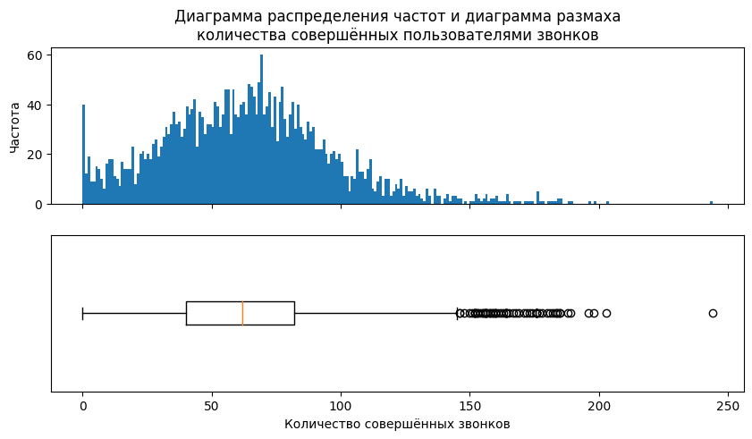

```python
fig, (ax1, ax2) = plt.subplots(2, 1, figsize=(10, 5))
ax1.set_title('Диаграмма распределения частот и диаграмма размаха' +
              '\nколичества совершённых пользователями звонков')
ax1.hist(data['calls'], bins=[n for n in range(245)])
ax1.tick_params(labelbottom=False)
ax1.set_ylabel('Частота')
ax2.boxplot(data['calls'], vert=False)
ax2.tick_params(left=False, labelleft=False)
ax2.set_xlabel('Количество совершённых звонков')
plt.show()
```

- Значения определены для всех записей.
- Значения определены с точностью до 1.
- Для 3214 записей встречается 184 различных уникальных значений.
- Минимальное значение — 0, максимальное значение — 244 звонка.
- Мода — 69 звонков, медиана — 62 звонка.
- Распределение унимодальное, практически симметричное. Смещено влево. С длинным "хвостом" справа.
- Наблюдается большое количество значений на нижней границе распределения — 0.
- Половина всех пользователей совершает 40–82 звонков.
- Практически все пользователи совершают не более 125 звонков. Большее количество звонков — явление редкое.

### Суммарная длительность звонков

```python
descriptive_statistics(data['minutes'], 'Суммарная длительность звонков, мин')
```

|  | Суммарная длительность звонков, мин |
| --- | --- |
| кол-во значений | 3214 |
| кол-во уникальных | 3144 |
| мин. | 0.0 |
| -1.5IQR | -15.42875 |
| 25 % | 274.58 |
| мода | [0.0] |
| медиана | 430.6 |
| среднее ариф. | 438.21 |
| 75 % | 571.93 |
| +1.5IQR | 876.62875 |
| макс. | 1632.06 |
| размах | 1632.06 |
| межквартильный размах | 297.3525 |

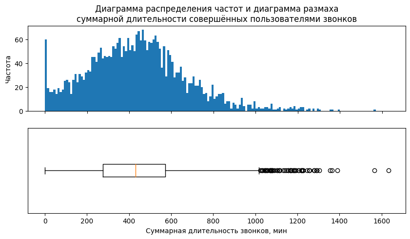

```python
fig, (ax1, ax2) = plt.subplots(2, 1, figsize=(10, 5))
ax1.set_title('Диаграмма распределения частот и диаграмма размаха' +
              '\nсуммарной длительности совершённых пользователями звонков')
ax1.hist(data['minutes'], [10*n for n in range(164)])
ax1.tick_params(labelbottom=False)
ax1.set_ylabel('Частота')
ax2.boxplot(data['minutes'], vert=False)
ax2.tick_params(left=False, labelleft=False)
ax2.set_xlabel('Cуммарная длительность звонков, мин')
plt.show()
```

- Значения определены для всех записей.
- Значения определены с точностью до 0,01 мин.
- Для 3214 записей встречается 3144 различных значений.
- Минимальное значение — 0, максимальное значение — 1632,06 мин.
- Мода — 0, медиана — 430,6 мин, среднее арифметическое — 438,21 мин.
- Распределение унимодальное, практически симметричное. Смещено влево. С длинным "хвостом" справа.
- Наблюдается большое количество значений на нижней границе распределения — 0.
- Половина всех пользователей тратит 275–572 мин.
- Практически все пользователи тратят не более 877 мин. Большее количество потраченных минут — явление редкое.

### Количество отправленных sms-сообщений

```python
descriptive_statistics(data['messages'],
                       'Количество отправленных sms-сообщений')
```

|  | Количество отправленных sms-сообщений |
| --- | --- |
| кол-во значений | 3214 |
| кол-во уникальных | 180 |
| мин. | 0.0 |
| -1.5IQR | -42.0 |
| 25 % | 9.0 |
| мода | [0.0] |
| медиана | 30.0 |
| среднее ариф. | 38.28 |
| 75 % | 57.0 |
| +1.5IQR | 102.0 |
| макс. | 224.0 |
| размах | 224.0 |
| межквартильный размах | 48.0 |

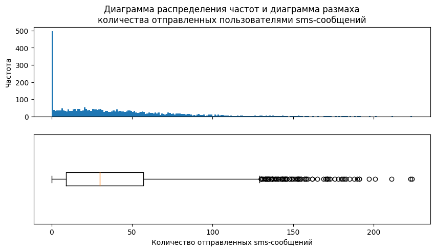

```python
fig, (ax1, ax2) = plt.subplots(2, 1, figsize=(10, 5))
ax1.set_title('Диаграмма распределения частот и диаграмма размаха' +
              '\nколичества отправленных пользователями sms-сообщений')
ax1.hist(data['messages'], bins=[n for n in range(225)])
ax1.tick_params(labelbottom=False)
ax1.set_ylabel('Частота')
ax2.boxplot(data['messages'], vert=False)
ax2.tick_params(left=False, labelleft=False)
ax2.set_xlabel('Количество отправленных sms-сообщений')
plt.show()
```

### Объём израсходованного интернет-трафика

```python
descriptive_statistics(data['mb_used'],
                       'Объём израсходованного интернет-трафика, Мбайт')
```

|  | Объём израсходованного интернет-трафика, Мбайт |
| --- | --- |
| кол-во значений | 3214 |
| кол-во уникальных | 3203 |
| мин. | 0.0 |
| -1.5IQR | 3544.03875 |
| 25 % | 12491.9 |
| мода | [0.0] |
| медиана | 16943.24 |
| среднее ариф. | 17207.67 |
| 75 % | 21424.7 |
| +1.5IQR | 30342.43125 |
| макс. | 49745.73 |
| размах | 49745.73 |
| межквартильный размах | 8932.7975 |

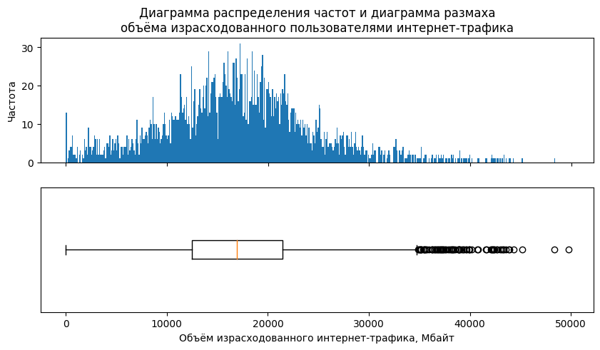

```python
fig, (ax1, ax2) = plt.subplots(2, 1, figsize=(10, 5))
ax1.set_title('Диаграмма распределения частот и диаграмма размаха' +
              '\nобъёма израсходованного пользователями интернет-трафика')
ax1.hist(data['mb_used'], bins=[100*n for n in range(498)])
ax1.tick_params(labelbottom=False)
ax1.set_ylabel('Частота')
ax2.boxplot(data['mb_used'], vert=False)
ax2.tick_params(left=False, labelleft=False)
ax2.set_xlabel('Объём израсходованного интернет-трафика, Мбайт')
plt.show()
```

- Значения определены для всех записей.
- Значения определены с точностью до 0,01 Мбайт.
- Для 3214 записей встречается 3203 различных значений.
- Минимальное значение — 0, максимальное значение — 49 745,73 Мбайт.
- Мода — 0, медиана — 16 943,24 Мбайт, среднее арифметическое — 17 207,67 Мбайт.
- Распределение унимодальное, практически симметричное. Смещено влево. С длинным "хвостом" справа.
- Наблюдается большое количество значений на нижней границе распределения — 0.
- Половина всех пользователей расходует 12 492–21 425 Мбайт.
- Практически все пользователи расходуют не более 30 342 Мбайт. Большее количество израсходованного интернет-трафика — явление редкое.

### Используемый тариф

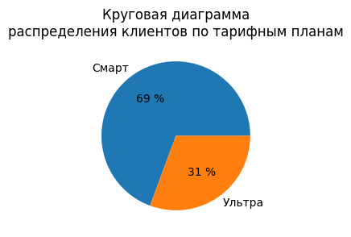

```python
labels = 'Смарт', 'Ультра'
plt.figure(figsize=(3, 3))
plt.pie(data['is_ultra'].value_counts(), labels=labels, autopct='%.0f %%')
plt.title('Круговая диаграмма\nраспределения клиентов по тарифным планам')
plt.show()
```

```python
pd.DataFrame(data['is_ultra'].value_counts()).T.rename(
    columns={0: 'Смарт', 1: 'Ультра'},
    index={'is_ultra': 'Кол-во клиентов, использующих тариф'})
```

|  | Смарт | Ультра |
| --- | --- | --- |
| Кол-во клиентов, использующих тариф | 2229 | 985 |

## Построение моделей

### Разделение данных на выборки

Выделим из данных целевой признак `is_ultra`.

```python
features = data.drop(['is_ultra'], axis=1)
target = data['is_ultra']
```

Поскольку отдельной тестовой выборки нет, разделим данные на тренировочную, валидационную и тестовую выборки в отношении 3 : 1 : 1. Таким образом, размеры валидационной и тестовой выборок будут равными.

```python
features_other, features_test, target_other, target_test = train_test_split(
    features, target, test_size=0.2, random_state=RANDOM_STATE)
features_train, features_valid, target_train, target_valid = train_test_split(
    features_other, target_other, test_size=0.25, random_state=RANDOM_STATE)
```

Посмотрим, какие выборки получились после разделения.

```python
features_train.shape
```

```
(1928, 4)
```

```python
features_valid.shape
```

```
(643, 4)
```

```python
features_test.shape
```

```
(643, 4)
```

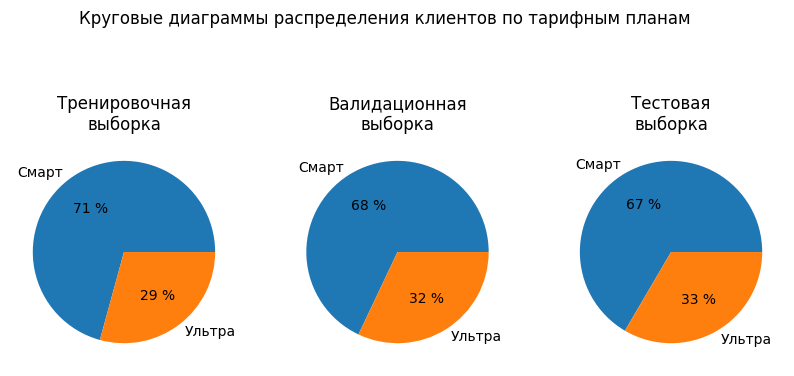

```python
labels = 'Смарт', 'Ультра'
fig, (ax1, ax2, ax3) = plt.subplots(1, 3, figsize=(10, 5))
ax1.pie(target_train.value_counts(), labels=labels, autopct='%.0f %%')
ax1.set_title('Тренировочная\nвыборка')
ax2.pie(target_valid.value_counts(), labels=labels, autopct='%.0f %%')
ax2.set_title('Валидационная\nвыборка')
ax3.pie(target_test.value_counts(), labels=labels, autopct='%.0f %%')
ax3.set_title('Тестовая\nвыборка')
fig.suptitle('Круговые диаграммы распределения клиентов по тарифным планам')
plt.show()
```

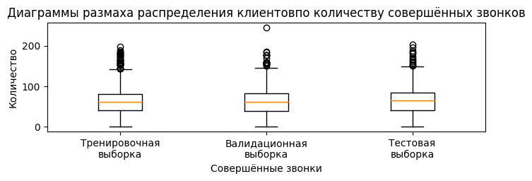

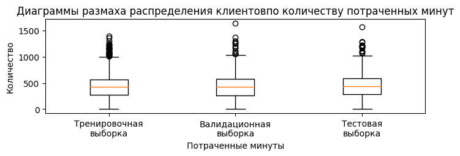

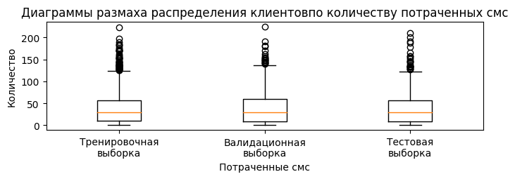

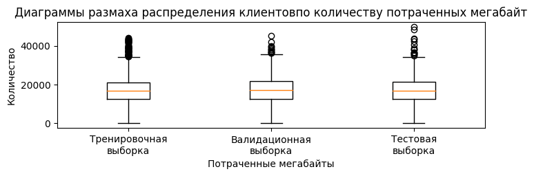

```python
for column_name in features.columns:
    columns_rename = {'calls': 'Совершённые звонки',
                      'minutes': 'Потраченные минуты',
                      'messages': 'Потраченные смс',
                      'mb_used': 'Потраченные мегабайты'}
    title_rename = {'calls': 'совершённых звонков',
                    'minutes': 'потраченных минут',
                    'messages': 'потраченных смс',
                    'mb_used': 'потраченных мегабайт'}
    plt.figure(figsize=(8, 2))
    plt.boxplot([
        features_train[column_name],
        features_valid[column_name],
        features_test[column_name],
    ])
    plt.title('Диаграммы размаха распределения клиентов' +
              f'по количеству {title_rename[column_name]}')
    plt.xticks([1, 2, 3], ['Тренировочная\nвыборка', 'Валидационная\nвыборка',
                           'Тестовая\nвыборка'])
    plt.xlabel(columns_rename[column_name])
    plt.ylabel('Количество')
    plt.show()
```

- Разделение данных на выборки (тренировочную, валидационную, тестовую) произведено удовлетворительно. Выборки получились репрезентативными. Основные статистические характеристики (например, медиана, межквартильный размах) принимают близкие значения.
- Соотношение потребителей, подключённых к тарифным планам "Смарт" и "Ультра", сохранено в каждой выборке приблизительно одинаковым и равным таковому отношению во всём наборе данных.

### Обучение моделей

Поскольку целевой признак `is_ultra` — категориальный (бинарный), следовательно, необходимо решить задачу бинарной классификации.

Зафиксируем псевдослучайность для алгоритмов обучения.

Оценку правильности обученной модели проведём, рассчитав значение отношение числа правильных ответов к размеру тестовой выборки.

Для того чтобы получить максимально высокое качество предсказания, нужно перебрать в алгоритмах обучения разные значения гиперпараметров: глубины дерева, количества деревьев или количества итераций (в регрессии).

Наилучшими гиперпараметрами для моделей классификации признаем те, при которых получится максимальное значение правильности обученной модели, оценённой на валидационной выборке.

#### Решающее дерево

```python
max_tree_depth = 50

best_dtc_model = None
best_dtc_accuracy = 0
best_dtc_accuracy_train = 0
best_tree_depth = 0

for depth in range(1, max_tree_depth+1):
    model = DecisionTreeClassifier(max_depth=depth,
                                   random_state=RANDOM_STATE)

    model.fit(features_train, target_train)

    predictions_train = model.predict(features_train)
    predictions_valid = model.predict(features_valid)

    accuracy_train = accuracy_score(target_train, predictions_train)
    accuracy_valid = accuracy_score(target_valid, predictions_valid)

    if accuracy_valid > best_dtc_accuracy:
        best_dtc_model = model
        best_dtc_accuracy = accuracy_valid
        best_dtc_accuracy_train = accuracy_train
        best_tree_depth = depth

print('Модель решающего дерева')
print('Максимальная правильность модели на валидационной выборке:',
      best_dtc_accuracy.round(3))
print('Соответствующая правильность модели на тренировочной выборке:',
      best_dtc_accuracy_train.round(3))
print('Глубина дерева:', best_tree_depth)
```

```
Модель решающего дерева
Максимальная правильность модели на валидационной выборке: 0.798
Соответствующая правильность модели на тренировочной выборке: 0.821
Глубина дерева: 4
```

#### Случайный лес

```python
max_tree_number = 70
max_tree_depth = 40

best_rfc_model = None
best_rfc_accuracy = 0
best_rfc_accuracy_train = 0
best_tree_numbers = 0
best_tree_depth = 0

for est in range(10, max_tree_number+1):
    for depth in range(1, max_tree_depth):
        model = RandomForestClassifier(n_estimators=est,
                                       max_depth=depth,
                                       random_state=RANDOM_STATE)

        model.fit(features_train, target_train)

        predictions_train = model.predict(features_train)
        predictions_valid = model.predict(features_valid)

        accuracy_train = accuracy_score(target_train, predictions_train)
        accuracy_valid = accuracy_score(target_valid, predictions_valid)

        if accuracy_valid > best_rfc_accuracy:
            best_rfc_model = model
            best_rfc_accuracy = accuracy_valid
            best_rfc_accuracy_train = accuracy_train
            best_tree_number = est
            best_tree_depth = depth

print('Модель случайного леса')
print('Максимальная правильность модели на валидационной выборке:',
      best_rfc_accuracy.round(3))
print('Соответствующая правильность модели на тренировочной выборке:',
      best_rfc_accuracy_train.round(3))
print('Количество деревьев в лесу:', best_tree_number)
print('Глубина каждого дерева:', best_tree_depth)
```

```
Модель случайного леса
Максимальная правильность модели на валидационной выборке: 0.813
Соответствующая правильность модели на тренировочной выборке: 0.902
Количество деревьев в лесу: 57
Глубина каждого дерева: 10
```

#### Логистическая регрессия

```python
max_iteration_number = 300

best_lr_model = None
best_lr_accuracy = 0
best_lr_accuracy_train = 0
best_lr_iteration_number = 0

for iteration_number in range(70, max_iteration_number+1):
    model = LogisticRegression(max_iter=iteration_number,
                               random_state=RANDOM_STATE)

    model.fit(features_train, target_train)

    predictions_train = model.predict(features_train)
    predictions_valid = model.predict(features_valid)

    accuracy_train = accuracy_score(target_train, predictions_train)
    accuracy_valid = accuracy_score(target_valid, predictions_valid)

    if accuracy_valid > best_lr_accuracy:
            best_lr_model = model
            best_lr_accuracy = accuracy_valid
            best_lr_accuracy_train = accuracy_train
            best_lr_iteration_number = iteration_number

print('Модель логистической регрессии')
print('Максимальная правильность модели на валидационной выборке:',
      best_lr_accuracy.round(3))
print('Соответствующая правильность модели на тренировочной выборке:',
      best_lr_accuracy_train.round(3))
print('Количество итераций:', best_lr_iteration_number)
```

```
Модель логистической регрессии
Максимальная правильность модели на валидационной выборке: 0.756
Соответствующая правильность модели на тренировочной выборке: 0.751
Количество итераций: 70
```

### Оценка моделей

#### Оценка правильности моделей

```python
predictions_test = best_dtc_model.predict(features_test)
accuracy_test = accuracy_score(target_test, predictions_test)

print('Модель решающего дерева')
print('Правильность модели на тестовой выборке:', accuracy_test.round(3))
```

```
Модель решающего дерева
Правильность модели на тестовой выборке: 0.774
```

```python
predictions_test = best_rfc_model.predict(features_test)
accuracy_test = accuracy_score(target_test, predictions_test)

print('Модель случайного леса')
print('Правильность модели на тестовой выборке:', accuracy_test.round(3))
```

```
Модель случайного леса
Правильность модели на тестовой выборке: 0.806
```

```python
predictions_test = best_lr_model.predict(features_test)
accuracy_test = accuracy_score(target_test, predictions_test)

print('Модель логистической регрессии')
print('Правильность модели на тестовой выборке:', accuracy_test.round(3))
```

```
Модель логистической регрессии
Правильность модели на тестовой выборке: 0.717
```

### Оценка адекватности моделей

Чтобы оценить адекватность моделей (проверить их на вменяемость), нужно сравнить обученные модели со случайной. Поскольку признак `is_ultra` является бинарным, наиболее простой моделью, пресказывающей тарифный план, будет такая, которая предсказывает самое частотное значение, то есть моду. Этот подход тем более правильный, поскольку частоты значений признака `is_ultra` разные.

```python
target_mode = pd.Series(target.median(), index=target_test.index)
target_mode.shape
```

```
(643,)
```

```python
accuracy_test = accuracy_score(target_mode, target_test)

print('Простая модель, предсказывающая самое распространённое значение')
print('Правильность простой модели на тестовой выборке:', accuracy_test.round(3))
```

```
Простая модель, предсказывающая самое распространённое значение
Правильность простой модели на тестовой выборке: 0.666
```

## Общий вывод

1. Были обучены модели бинарной классификации: решающее дерево, случайный лес, логистическая регрессия.
- Для каждого алгоритма было обучено несколько моделей с различными гиперпараметрами.
- Критерием выбора лучшей модели было максимальное значение правильности, достигнутого на валидационной выборке.  
  Оно составило:
  - для решающего дерева — 0,798;
  - для случайного леса — 0,813;
  - для логистической регрессии — 0,756.
- Максимальное значение правильности (0,813) достигнуто для модели случайного леса: количество деревьев в лесу — 57, максимальная глубина дерева — 10. Правильность модели на тренировочной выборке (0,902) выше значения правильности для валидационной выборки. Это не говорит о переобучении модели, поскольку оба значения высокие.
- Следующей моделью по максимально достигнутому значению правильности (0,798) идёт решающее дерево с максимальной глубиной дерева — 4. Правильность модели на тренировочной выборке (0,821) незначительно выше значения правильности для валидационной выборки.
- Наименьшее значение правильности (0,756) достигнуто для модели логистической регрессии: количество итераций — 70. Значение правильности модели на тренировочной выборке (0,751) схоже со значением правильности, полученного на валидационной выборке.
2. Правильность обученных моделей бинарной классификации с максимально достигнутым значением правильности на валидационной выборке проверена на тестовой выборке.
- Распределение значений правильности обученных моделей для тестовой выборки повторяет распределение для валидационной выборки:
  - для случайного леса (57 деревьев с максимальной глубиной дерева 10) — 0,806;
  - для решающего дерева (с максимальной глубиной дерева 4) — 0,774;
  - для логистической регрессии (с числом итераций 70) — 0,717.
3. Оценка адекватности моделей проведена путём сопоставления правильности обученных моделей с правильностью простой модели, предсказывающей наиболее распространённое значение.
- Правильность простой модели, предсказывающей наиболее распространённое значение, на тестовой выборке составило 0,666.
- Все обученные модели имеют значение правильности на тестовой выборке выше, чем у простой модели
  - для случайного леса на $\frac{0,806}{0,666}-1=0,21=21 \%$;
  - для решающего дерева на $\frac{0,774}{0,666}-1=0,16=16 \%$;
  - для логистической регрессии на $\frac{0,717}{0,666}-1=0,08=8 \%$.
4. Для построения системы, которая выберет подходящий тарифный план "Смарт" или "Ультра" рекомендуется использовать обученную модель случайного леса с количеством деревьев 57 и максимальной глубиной одного дерева 10.